# Assignment 1: Data set selection and initial Processing

Advait Sridhar

February 15th, 2022

**Brief Introduction**: The dataset of interest is GSE173940 and can be found here: https://www.ncbi.nlm.nih.gov/geo/query/acc.cgi?acc=GSE173940. It was found through the NCBI Gene Expression Omnibus (GEO) and involves the investigation of ATM checkpoint kinase loss on cerebral protein aggregation. The researchers used 2 cell lines with 3 treatments and one control population in each group and investigated expression of ATM and relevant topoisomerase and checkpoint kinase genes as a result. I will be investigating the statistical quality of the data using the Bioconductor package in R.

```r
#Setting Working Directory
setwd("/home/rstudio/projects")
getwd()
```

```
## [1] "/home/rstudio/projects"
```

```r
#Installing and Loading Required Packages
if (!requireNamespace("BiocManager", quietly = TRUE))
    install.packages("BiocManager")
if (!requireNamespace("GEOquery", quietly = TRUE))
    BiocManager::install("GEOquery")
if (!requireNamespace("GEOmetadb", quietly = TRUE))
    BiocManager::install("GEOmetadb")
if (!require("edgeR", quietly = TRUE))
    BiocManager::install("edgeR")
if (!requireNamespace("biomaRt", quietly = TRUE))
    BiocManager::install("biomaRt")
if (!requireNamespace("tidyverse", quietly = TRUE))
    install.packages("tidyverse")
if (!requireNamespace("knitr", quietly = TRUE))
    install.packages("knitr")


library(BiocManager)
library(GEOquery)
library(GEOmetadb)
library(tidyverse)
library(knitr)
library(edgeR)
library(biomaRt)
```

**1 - Download the data**

Data was downloaded using GEOquery package. Rownames correspond to the ensembl ids in the downloaded file, and the read.delim() function was used to write it into a data frame.

```r
#Downloading the Data
data_file <- getGEOSuppFiles('GSE173940')
gene_names <- rownames(data_file)

#Reading ensembl ids and expression data into data frame
atm_exp <- read.delim(gene_names[1], header=TRUE, check.names = FALSE)
```

**2 - Assess**

The size of the dataset was investigated using dim()

```r
#Finding number of rows and columns in the dataset
dim(atm_exp)
```

```
## [1] 60204    33
```

Seeing that there are 33 columns, I proceeded to investigate column names to see if control and treatment groups could be parsed from them.

```r
#Looking at column names
colnames(atm_exp)
```

```
##  [1] ""         "Wouter18" "Wouter19" "Wouter20" "Wouter21" "Wouter22"
##  [7] "Wouter23" "Wouter24" "Wouter25" "Wouter26" "Wouter27" "Wouter28"
## [13] "Wouter29" "Wouter30" "Wouter31" "Wouter32" "Wouter33" "Wouter1"
## [19] "Wouter10" "Wouter11" "Wouter12" "Wouter13" "Wouter14" "Wouter15"
## [25] "Wouter16" "Wouter17" "Wouter2"  "Wouter3"  "Wouter4"  "Wouter5"
## [31] "Wouter6"  "Wouter7"  "Wouter8"
```

Seeing as the column names were generic and not organized in any particular order, I found the corresponding groups and their treatment for each sample through the GEO website and created two vectors to represent this. I compiled the vectors into a dataframe called “samples” for later analysis.

```r
#creating list of treatments that weren't included in original data
treatment <- c("WT", "Camptothecin", "DMSO", "Camptothecin", "DMSO", "Camptothecin", "DMSO", "Camptothecin", "ATM-KO", "WT", "ATM-KO", "WT", "ATM-KO", "WT", "ATM-KO", "DMSO", "ATM-KO", "ATM-KO", "ATM-KO", "ATM-KO", "DMSO", "DMSO", "DMSO", "DMSO", "Camptothecin", "Camptothecin", "Camptothecin", "Camptothecin", "DMSO", "DMSO", "DMSO", "DMSO")

#creating list of cell lines used for experimentation
cell_line <- c("U2OS", "HEK293T", "HEK293T", "HEK293T", "HEK293T", "HEK293T", "HEK293T", "HEK293T", "U2OS", "U2OS", "U2OS", "U2OS", "U2OS", "U2OS", "U2OS", "HEK293T", "HEK293T", "HEK293T", "HEK293T", "HEK293T", "HEK293T", "HEK293T", "HEK293T", "HEK293T", "U2OS", "U2OS", "U2OS", "U2OS", "U2OS", "U2OS", "U2OS", "U2OS")

#compiling cell lines and treatment information into a data frame
samples <- data.frame(cell_line, treatment)
kable(table(samples$treatment[1:3]), format = "html")
```

| Var1 | Freq |
| --- | --- |
| Camptothecin | 1 |
| DMSO | 1 |
| WT | 1 |

**3 - Map**

The most important step involved mapping the ensemble ids into their respective HUGO symbols. I was able to do this using biomaRt package and submitting a query using attributes “ensembl_gene_id” and “hgnc_symbol” to retrieve the relevant symbols. The list of genes was then merged into the original dataset and the columns were ordered alphanumerically as they had been mixed up when initially downloaded.

```r
#renaming first column prior to mapping
colnames(atm_exp)[1] <- "ensembl_id"

#ensuring configuration works prior to submitting query
httr::set_config(httr::config(ssl_verifypeer = FALSE))

#defining ensembl variable to pull values from dataset
ensembl <- useMart("ensembl")
ensembl <- useDataset("hsapiens_gene_ensembl", mart=ensembl)

#querying biomaRt to get HUGO gene symbols for ensembl ids
genes <- atm_exp$ensembl_id
gene_list <- getBM(filters = "ensembl_gene_id", attributes = c("ensembl_gene_id", "hgnc_symbol"), values = genes, mart = ensembl)
```

[output not shown]

```r
#merging to original dataset
atm_exp <- merge(atm_exp,gene_list,by.x="ensembl_id",by.y="ensembl_gene_id")

#order alphanumerically
atm_exp <- atm_exp[,str_sort(names(atm_exp), numeric = TRUE)]
kable(table(atm_exp$hgnc_symbol[1:10]), format = "html")
```

| Var1 | Freq |
| --- | --- |
| C1orf112 | 1 |
| CFH | 1 |
| DPM1 | 1 |
| FGR | 1 |
| FUCA2 | 1 |
| GCLC | 1 |
| NFYA | 1 |
| SCYL3 | 1 |
| TNMD | 1 |
| TSPAN6 | 1 |

**3 - Clean**

After creating our sorted dataset with HUGO symbols, we need to get rid of irrelevant data prior to normalization. I started by getting rid of the last 5 rows, which had data involving numbers of replicates that weren’t assigned to any samples and random noise that researchers couldn’t assign to any one gene id. The data was then sorted in descending order. Seeing that none of the identifiers mapped to more than 1 gene, there was no need for further cleaning for this part.

```r
#omitting irrelevant rows
atm_exp <- atm_exp[-c(60200:60204), ]

#sorting by gene counts (none exceed 1)
atm_gene_counts <- sort(table(atm_exp$ensembl_id), decreasing = TRUE)
kable(table(atm_exp$hgnc_symbol)[1:10], format="html")
```

| Var1 | Freq |
| --- | --- |
|  | 17611 |
| A1BG | 1 |
| A1BG-AS1 | 1 |
| A1CF | 1 |
| A2M | 1 |
| A2M-AS1 | 1 |
| A2ML1 | 1 |
| A2ML1-AS1 | 1 |
| A2ML1-AS2 | 1 |
| A2MP1 | 1 |

```r
#convert to counts per million
cpms <- cpm(atm_exp[,3:34])
rownames(cpms) <- atm_exp[,2]

#removing low counts in each row to create filtered dataset
keep <- rowSums(cpms >1) >=10
atm_exp_filtered <- atm_exp[keep,]

#finding number of deleted rows
kable(length(rownames(atm_exp)) - length(rownames(atm_exp_filtered)), format = "html")
```

| x |
| --- |
| 40352 |

**Normalization**

As seen above, there was an immense number of genes that were removed as a result of filtering out low counts. Now, we need to normalize the data to account for variation and quality of what I will be working with. To see the spread of the data, I created a boxplot using expression values to ensure median and end values were comparable. I didn’t include outliers since there seemed to be many of them in all samples, which I checked by removing the outline = FALSE argument and it didn’t seem to make much of a difference to the overall distribution of median and end points for all samples.

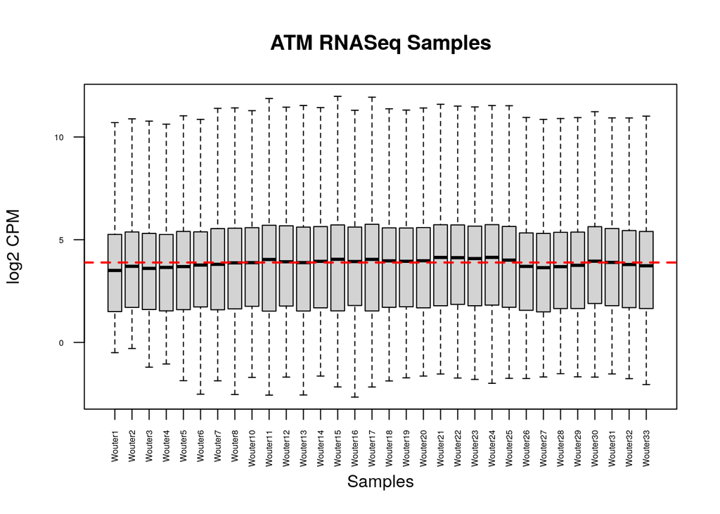

```r
#creating a boxplot to visualize data without outliers
atm_boxplot <- log2(cpm(atm_exp_filtered[,3:34]))

boxplot(atm_boxplot, xlab = "Samples", ylab = "log2 CPM",
        las = 2, cex = 0.5, cex.lab = 1,
        cex.axis = 0.5, main = "ATM RNASeq Samples", outline = FALSE)

#median of the data
abline(h = median(apply(atm_boxplot, 2, median)),
       col = "red", lwd = 2, lty = "dashed")
```

By naked eye, I could see that the median value of gene cpm of each sample didn’t vary greatly from the median of the whole sample or each other. To further confirm this, I constructed a density plot to ensure that the data was normally distributed.

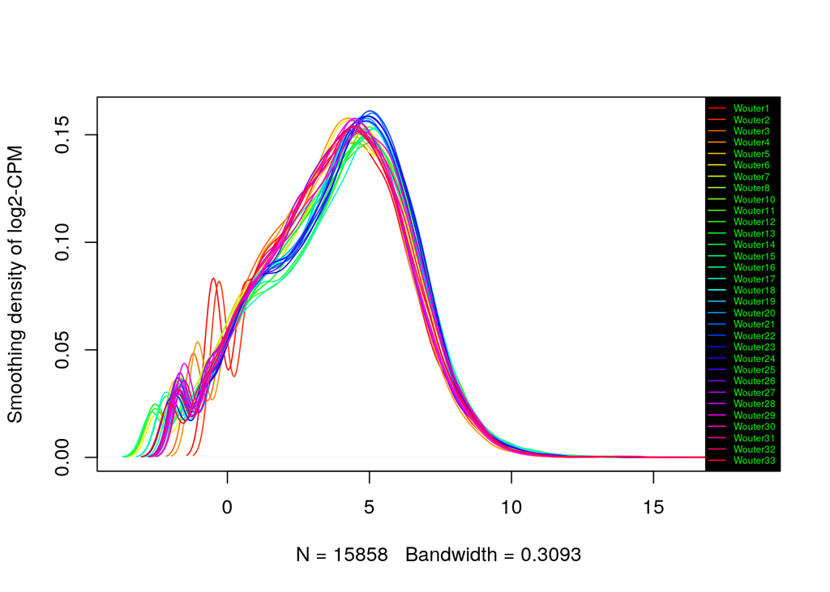

```r
#creating a density plot
atm_counts_density <- apply(log2(cpm(atm_exp_filtered[,3:34])), 2, density)

#calculate the limit for each sample
xlim <- 0
ylim <- 0

#using a for loop to iterate through expression values for each sample as a log2 of its gene cpm
for (i in 1:length(atm_counts_density)) {
  xlim <- range(c(xlim, atm_counts_density[[i]]$x))
  ylim <- range(c(ylim, atm_counts_density[[i]]$y))
    }

#indicating color and line type
cols <- rainbow(length(atm_counts_density))
ltys <- rep(1, length(atm_counts_density))

#initial density plot
plot(atm_counts_density[[1]], xlim=xlim, ylim=ylim, type="n",
     ylab="Smoothing density of log2-CPM",
     main="", cex.lab = 1.0)

#full plot
for (i in 1:length(atm_counts_density))
  lines(atm_counts_density[[i]], col=cols[i], lty=ltys[i])

#legend
legend("right", colnames(atm_boxplot),
       col=cols, lty=ltys, cex=0.48,
       border ="red",  text.col = "green",
       merge = TRUE, bg = "black")
```

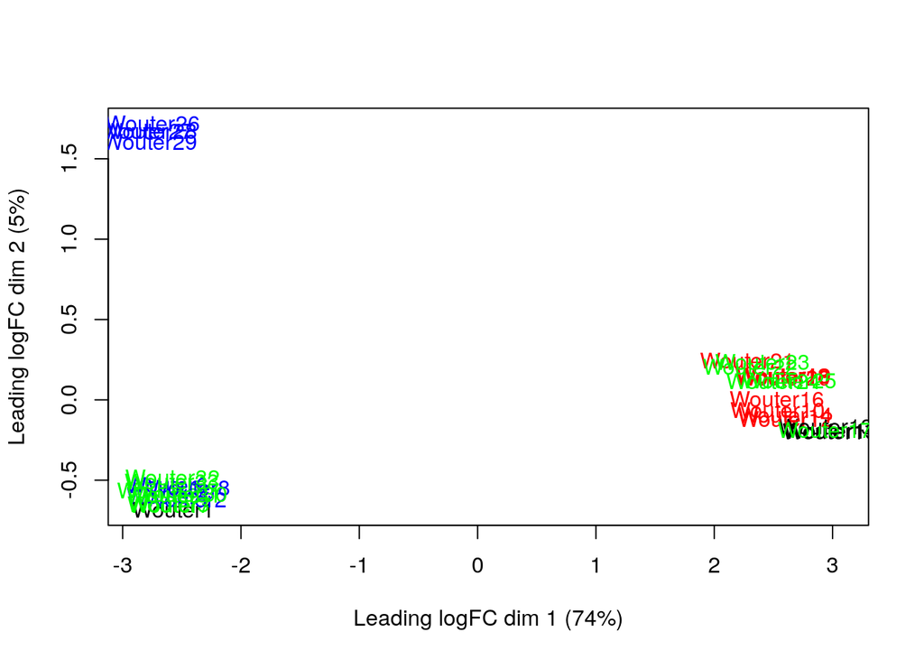

```r
#inputting ordered sample names into samples dataframe
rownames(samples) <- colnames(atm_exp[,3:34])

#creating an edgeR container for count data
filtered_data_matrix <- as.matrix(atm_exp_filtered[,3:34])
rownames(filtered_data_matrix) <- atm_exp_filtered$hgnc_symbol
d = DGEList(counts=filtered_data_matrix, group=samples$treatment)

#calculating normalization factors
d = calcNormFactors(d)

#getting the normalized data
normalized_counts <- cpm(d)

#creating an MDS plot
plotMDS(d, labels=rownames(samples),
  col = c("red", "blue", "green", "black")[factor(samples$treatment)])
```

Through this plot, we can see which samples cluster together and which ones don’t. The degree of sample separation here appears to be quite high, which warrants further investigation. We can also use our DGEList object to create a BCV plot, which calculates dispersion and allows us to see how much our variance deviates from the mean of the sample data. I specifically compared the variables of interest to the researchers, which was the 2 cell lines and their 4 treatments (including a control), and plotted common and tagwise dispersio as a result.

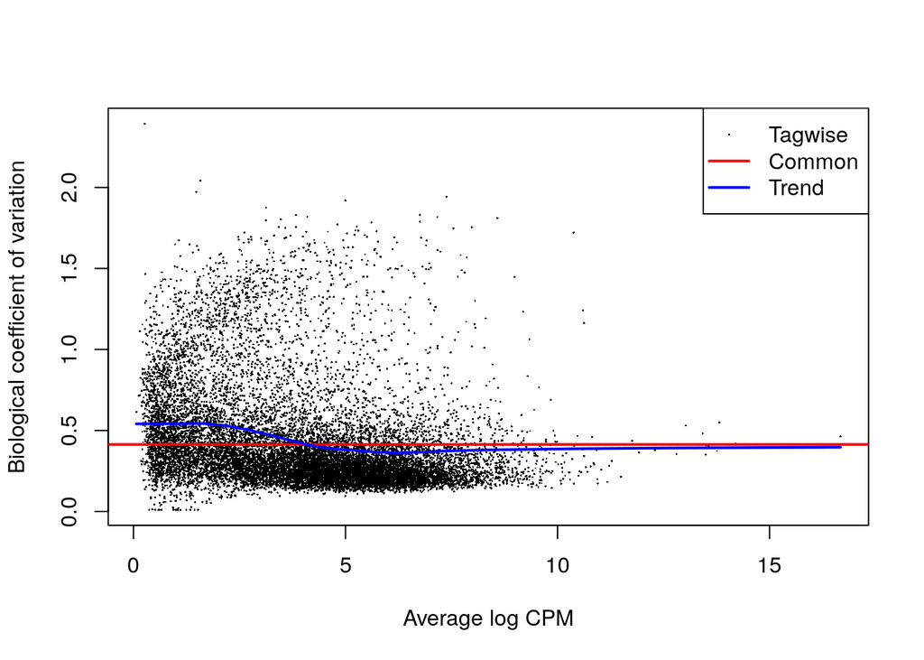

```r
#estimate common and tagwise dispersion between cell line and treatment used
model_design <- model.matrix(~samples$cell_line + samples$treatment+0)
d <- estimateDisp(d, model_design)

#Creating BCV plot to investigate dispersion
plotBCV(d)
```

The BCV plot shows that at higher log cpm there seems to be less difference between mean and variance, but it is exacerbated at lower values.To investigate this further, I created a mean-variance plot to highlight correlation between mean and variance for both tagwise and common dispersion data using the plotMeanVar() function with the DGEList object as an argument and displaying all relationships.

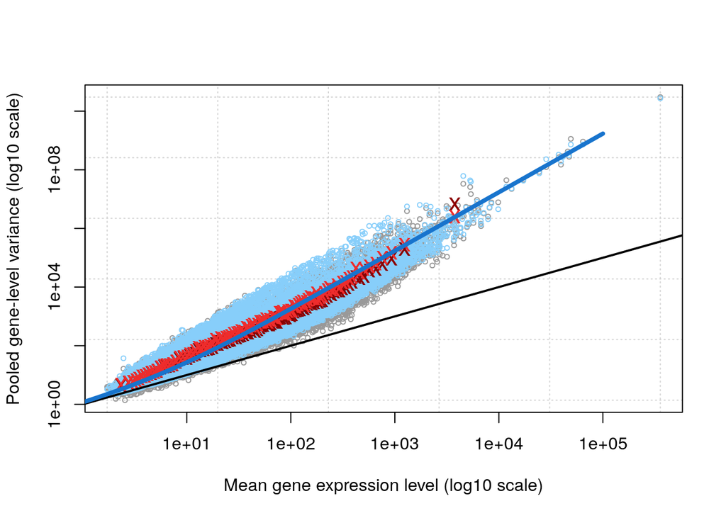

```r
#Investigating relationship between mean and variance of expression data
plotMeanVar(d, show.raw.vars = TRUE, show.tagwise.vars=TRUE, NBline=TRUE,
            show.ave.raw.vars = TRUE,show.binned.common.disp.vars = TRUE)
```

The plot shows a much more promising correlation between mean and variance of the sample data, although it is hard to tell for sure due to the immense amount of data points and lack of taking into account its variance from the best fit line. The raw variation and tagwise dispersion fall into a similar pattern, as does the average variation and common dispersion. All these factors indicate that the data has been normalized to the point where it is suitable for further analysis.

**FINAL PRODUCT: MAPPING HUGO SYMBOLS TO ENSEMBL GENE IDENTIFIERS**

```r
#Making rownames HUGO symbols
rownames(atm_exp_filtered) <- make.names(atm_exp_filtered$hgnc_symbol, unique = TRUE)

#Removing ensembl_id and hgnc_symbol columns
atm_exp_filtered <- atm_exp_filtered[,-1:-2]

#Writing data to local file
write.csv(atm_exp_filtered,"atm_exp_filtered.csv", row.names = TRUE)

#Displaying final dataset
result <- atm_exp_filtered
kable(head(result), format = "html")
```

|  | Wouter1 | Wouter2 | Wouter3 | Wouter4 | Wouter5 | Wouter6 | Wouter7 | Wouter8 | Wouter10 | Wouter11 | Wouter12 | Wouter13 | Wouter14 | Wouter15 | Wouter16 | Wouter17 | Wouter18 | Wouter19 | Wouter20 | Wouter21 | Wouter22 | Wouter23 | Wouter24 | Wouter25 | Wouter26 | Wouter27 | Wouter28 | Wouter29 | Wouter30 | … |
| --- | --- | --- | --- | --- | --- | --- | --- | --- | --- | --- | --- | --- | --- | --- | --- | --- | --- | --- | --- | --- | --- | --- | --- | --- | --- | --- | --- | --- | --- | --- |
| TSPAN6 | 191 | 91 | 217 | 199 | 581 | 591 | 401 | 666 | 721 | 1705 | 691 | 1738 | 735 | 1268 | 1500 | 1268 | 846 | 836 | 845 | 930 | 927 | 819 | 1109 | 937 | 418 | 417 | 388 | 427 | 505 | … |
| TNMD | 0 | 0 | 0 | 0 | 0 | 0 | 0 | 0 | 7 | 7 | 9 | 5 | 6 | 5 | 17 | 5 | 6 | 7 | 5 | 3 | 3 | 5 | 9 | 3 | 0 | 0 | 0 | 0 | 0 | … |
| DPM1 | 82 | 60 | 98 | 55 | 232 | 209 | 168 | 189 | 211 | 353 | 174 | 232 | 240 | 315 | 191 | 393 | 120 | 125 | 130 | 195 | 205 | 198 | 216 | 147 | 153 | 154 | 119 | 144 | 193 | … |
| SCYL3 | 12 | 7 | 17 | 6 | 20 | 40 | 19 | 30 | 28 | 74 | 48 | 79 | 41 | 88 | 81 | 66 | 54 | 43 | 42 | 53 | 46 | 45 | 66 | 57 | 14 | 18 | 15 | 18 | 22 | … |
| C1orf112 | 26 | 18 | 33 | 26 | 55 | 100 | 66 | 67 | 55 | 113 | 39 | 79 | 52 | 89 | 103 | 83 | 83 | 78 | 72 | 69 | 85 | 64 | 86 | 70 | 31 | 38 | 41 | 43 | 56 | … |
| FUCA2 | 95 | 112 | 82 | 158 | 286 | 594 | 220 | 565 | 164 | 435 | 146 | 383 | 153 | 325 | 285 | 316 | 193 | 160 | 217 | 219 | 230 | 231 | 282 | 213 | 230 | 285 | 221 | 271 | 174 | … |

**Interpret & Document**

**What are the control and test conditions of the dataset?**

The control condition of this dataset is the WT treatment for the U2OS cells. The test conditions are the Camptothecin, DMSO, and ATM-knockout treatments for both cell lines.

**Why is the dataset of interest to you?**

I have a deep interest in protein aggregation in specific, and cancer genetics in general. The knockout of ATM kinase and the introduction of genotoxic elements may have large influence in protein aggregation especially with age, and so I was deeply interested in the gene expression results of these conditions on human cells.

**Were there expression values that were not unique for specific genes? How did you handle these?**

I did not find such expression values in my dataset.

**How many outliers were removed?**

Outliers weren’t removed as part of the dataset, although they were hidden while creating the boxplot.

**How did you handle replicates?**

Biological replicates in this dataset involved two cell lines taken from 32 samples and treated with 4 treatments. I treated the cell lines as groups, with each having one of 4 possible treatments (including a control) and this whole process being repeated 4 times for a total of 32 outcomes.

**What is the final coverage of your dataset?**

The total coverage of the dataset was the number of counts in the filtered file/number of counts in the original dataset which was 15858/56210 = **28.2%**